# Network of Foreign Policy Experts

2019/3/8

## Question

## From Panda Huggers to Rivarly

- Why the foreign policy changes, especially the changes of US views towrad China
- The classical IR answer
  - Realism (Here comes Mearsheimer)
  - Thucydides Trap by Graham Allison

## Why I am not a big fan of these answers

- The presumption of nation state as the only player
- The dynamics among policy makers is not captured by the theory
  - Why the changes of U.S happened in recent years? (why not five years ago?)
  - Why the changes are so fast and bipartisan?

## A network approach

## What Network

- Foreign policy elites network constituted by
  - Academic, Journalists, Career Diplomat and Militaries
- Structure of Network matters
  - Duality of Network
    - The organization network
    - The network of elites
  - Cliques and Structual Holes
    - Some elites' changes of mind can have tremendous fallout effect

## Empirical Strategies

- A sampling list from the authorship in Foreign Affairs
  - Search in title and abstract for *China*
- The biographical data from the internet
  - The employment history
    - Gov Employee, Gov Consultant
  - Institutions on elite has been stayed
    - Think Tank, University, Committees
  - Exclude journalists

## Preliminary Research Questions

- What network do Republican and Democrats rely on?
- On the elite network
  - Actors' prominance
    - centrality (could be a regression)
  - Group Effect
    - k-cores
    - community effect
  - Model
    - Block Model
    - ERGM ?

## Data and Results

## Raw data

| Name | appointment_obama | appointment_bush | gov_consultant | gov_employee | NationalCommitteeOnUSChinaRelations | WorldBank | CFR | Brookings | Carneigie | RAND | Cato | CenterNationalInterest | PIIE | CenterNewAmericanSecurity | ForeignPolicyResearchInstitute | IISS | AEI | Aspen | WilsonCenter | CSIS | NationalBureauAsianResearch | AsiaFoundation | PacificCouncilInternationalPolicy | EWCenter | Eurasia | CNA | NED | NewAmerica | FreedomHouse | … |
| --- | --- | --- | --- | --- | --- | --- | --- | --- | --- | --- | --- | --- | --- | --- | --- | --- | --- | --- | --- | --- | --- | --- | --- | --- | --- | --- | --- | --- | --- | --- |
| Eliot Cohen | 0 | 1 | 1 | 1 | 0 | 0 | 1 | 0 | 0 | 0 | 0 | 0 | 0 | 0 | 0 | 1 | 0 | 1 | 0 | 0 | 0 | 0 | 0 | 0 | 0 | 0 | 0 | 0 | 0 | … |
| Bates Gill | 0 | 0 | 0 | 0 | 0 | 0 | 0 | 1 | 0 | 0 | 0 | 0 | 0 | 0 | 0 | 0 | 0 | 0 | 0 | 1 | 0 | 0 | 0 | 0 | 0 | 0 | 0 | 0 | 0 | … |
| Michael Mandelbaum | 0 | 0 | 0 | 0 | 0 | 0 | 0 | 0 | 0 | 0 | 0 | 0 | 0 | 0 | 0 | 0 | 0 | 0 | 0 | 0 | 0 | 0 | 0 | 0 | 0 | 0 | 0 | 0 | 0 | … |
| Robert Ross | 0 | 0 | 1 | 0 | 1 | 0 | 1 | 1 | 0 | 0 | 0 | 0 | 0 | 0 | 0 | 0 | 0 | 0 | 0 | 0 | 0 | 0 | 0 | 0 | 0 | 0 | 0 | 0 | 0 | … |
| Donald Zagoria | 0 | 0 | 1 | 0 | 0 | 0 | 1 | 0 | 0 | 1 | 0 | 0 | 0 | 0 | 0 | 0 | 0 | 0 | 0 | 0 | 0 | 0 | 0 | 0 | 0 | 0 | 0 | 0 | 0 | … |
| Andrew Nathan | 0 | 0 | 1 | 0 | 1 | 0 | 0 | 0 | 0 | 0 | 0 | 0 | 0 | 0 | 0 | 0 | 0 | 0 | 0 | 0 | 0 | 0 | 0 | 0 | 0 | 0 | 1 | 0 | 1 | … |
| Jonathan Hecht | 0 | 0 | 1 | 1 | 0 | 0 | 0 | 0 | 0 | 0 | 0 | 0 | 0 | 0 | 0 | 0 | 0 | 0 | 0 | 0 | 0 | 0 | 0 | 0 | 0 | 0 | 0 | 0 | 0 | … |
| Ramon Myers | 0 | 0 | 0 | 0 | 0 | 0 | 0 | 0 | 0 | 0 | 0 | 0 | 0 | 0 | 0 | 0 | 0 | 0 | 0 | 0 | 0 | 0 | 0 | 0 | 0 | 0 | 0 | 0 | 0 | … |
| Thomas Metzger | 0 | 0 | 0 | 0 | 0 | 0 | 0 | 0 | 0 | 0 | 0 | 0 | 0 | 0 | 0 | 0 | 0 | 0 | 0 | 0 | 0 | 0 | 0 | 0 | 0 | 0 | 0 | 0 | 0 | … |
| Milton Mueller | 0 | 0 | 0 | 0 | 0 | 0 | 0 | 0 | 0 | 0 | 0 | 0 | 0 | 0 | 0 | 0 | 0 | 0 | 0 | 0 | 0 | 0 | 0 | 0 | 0 | 0 | 0 | 0 | 0 | … |
| Zixiang Tan | 0 | 0 | 0 | 0 | 0 | 0 | 0 | 0 | 0 | 0 | 0 | 0 | 0 | 0 | 0 | 0 | 0 | 0 | 0 | 0 | 0 | 0 | 0 | 0 | 0 | 0 | 0 | 0 | 0 | … |
| Chae-Jin Lee | 0 | 0 | 0 | 0 | 0 | 0 | 0 | 0 | 0 | 0 | 0 | 0 | 0 | 0 | 0 | 0 | 0 | 0 | 0 | 0 | 0 | 0 | 1 | 0 | 0 | 0 | 0 | 0 | 0 | … |
| Steven Radelet | 1 | 1 | 1 | 1 | 0 | 0 | 0 | 1 | 0 | 0 | 0 | 0 | 0 | 0 | 0 | 0 | 0 | 0 | 0 | 0 | 0 | 0 | 0 | 0 | 0 | 0 | 0 | 0 | 0 | … |
| Jeffrey Sachs | 0 | 0 | 1 | 0 | 0 | 0 | 0 | 0 | 0 | 0 | 0 | 0 | 0 | 0 | 0 | 0 | 0 | 0 | 0 | 0 | 0 | 0 | 0 | 0 | 0 | 0 | 0 | 0 | 0 | … |
| Ezra Vogel | 0 | 0 | 1 | 1 | 0 | 0 | 0 | 0 | 0 | 0 | 0 | 0 | 0 | 0 | 0 | 0 | 0 | 0 | 0 | 0 | 0 | 0 | 0 | 0 | 0 | 0 | 0 | 0 | 0 | … |
| Richard Cooper | 0 | 0 | 1 | 1 | 0 | 0 | 0 | 0 | 0 | 0 | 0 | 0 | 0 | 0 | 0 | 0 | 0 | 0 | 0 | 0 | 0 | 0 | 0 | 0 | 0 | 0 | 0 | 0 | 0 | … |
| Minxin Pei | 0 | 0 | 0 | 0 | 0 | 0 | 0 | 0 | 1 | 0 | 0 | 0 | 0 | 0 | 0 | 0 | 0 | 0 | 0 | 0 | 0 | 0 | 0 | 0 | 0 | 0 | 0 | 0 | 0 | … |
| Neil Hughes | 0 | 0 | 0 | 0 | 0 | 1 | 0 | 0 | 0 | 0 | 0 | 0 | 0 | 0 | 0 | 0 | 0 | 0 | 0 | 0 | 0 | 0 | 0 | 0 | 0 | 0 | 0 | 0 | 0 | … |
| Nicholas Lardy | 0 | 0 | 0 | 0 | 1 | 0 | 1 | 1 | 0 | 0 | 0 | 0 | 1 | 0 | 0 | 0 | 0 | 0 | 0 | 0 | 0 | 0 | 0 | 0 | 0 | 0 | 0 | 0 | 0 | … |
| Ted Galen Carpenter | 0 | 0 | 0 | 0 | 0 | 0 | 0 | 0 | 0 | 0 | 1 | 0 | 0 | 0 | 0 | 0 | 0 | 0 | 0 | 0 | 0 | 0 | 0 | 0 | 0 | 0 | 0 | 0 | 0 | … |
| David Shambaugh | 0 | 0 | 0 | 1 | 1 | 0 | 0 | 1 | 0 | 0 | 0 | 0 | 0 | 0 | 0 | 0 | 0 | 0 | 0 | 0 | 0 | 0 | 0 | 0 | 0 | 0 | 0 | 0 | 0 | … |
| Denny Roy | 0 | 1 | 1 | 1 | 0 | 0 | 0 | 0 | 0 | 0 | 0 | 0 | 0 | 0 | 0 | 0 | 0 | 0 | 0 | 0 | 0 | 0 | 0 | 1 | 0 | 0 | 0 | 0 | 0 | … |
| Bruce Dickson | 0 | 0 | 0 | 0 | 1 | 0 | 0 | 0 | 0 | 0 | 0 | 0 | 0 | 0 | 0 | 0 | 0 | 0 | 0 | 0 | 0 | 0 | 0 | 0 | 0 | 0 | 0 | 0 | 0 | … |
| Peter Rodman | 0 | 1 | 1 | 1 | 0 | 0 | 0 | 1 | 0 | 0 | 0 | 0 | 0 | 0 | 0 | 0 | 0 | 0 | 0 | 0 | 0 | 0 | 0 | 0 | 0 | 0 | 0 | 0 | 0 | … |
| Elizabeth Economy | 0 | 0 | 1 | 1 | 1 | 0 | 1 | 0 | 0 | 0 | 0 | 0 | 0 | 0 | 0 | 0 | 0 | 0 | 0 | 0 | 0 | 1 | 0 | 0 | 0 | 0 | 0 | 0 | 0 | … |
| Lucian Pye | 0 | 0 | 1 | 0 | 1 | 0 | 1 | 0 | 0 | 0 | 0 | 0 | 0 | 0 | 0 | 0 | 0 | 0 | 0 | 0 | 0 | 1 | 0 | 0 | 0 | 0 | 0 | 0 | 0 | … |
| Richard H. Solomon | 0 | 0 | 0 | 1 | 0 | 0 | 0 | 0 | 0 | 0 | 0 | 0 | 0 | 0 | 0 | 0 | 0 | 0 | 0 | 0 | 0 | 0 | 0 | 0 | 0 | 0 | 0 | 0 | 0 | … |
| Susan Shirk | 0 | 0 | 1 | 1 | 1 | 1 | 1 | 0 | 0 | 0 | 0 | 0 | 0 | 0 | 0 | 1 | 0 | 1 | 0 | 0 | 0 | 0 | 1 | 1 | 0 | 0 | 0 | 0 | 0 | … |
| Ronald Montaperto | 0 | 0 | 0 | 1 | 0 | 0 | 0 | 0 | 0 | 0 | 0 | 0 | 0 | 0 | 0 | 0 | 0 | 0 | 0 | 0 | 0 | 0 | 0 | 0 | 0 | 0 | 0 | 0 | 0 | … |
| Edward Steinfeld | 0 | 0 | 0 | 0 | 1 | 1 | 0 | 0 | 0 | 0 | 0 | 0 | 0 | 0 | 0 | 0 | 0 | 0 | 0 | 0 | 0 | 0 | 0 | 0 | 0 | 0 | 0 | 0 | 0 | … |

[output cut: 116 more lines]

## The network

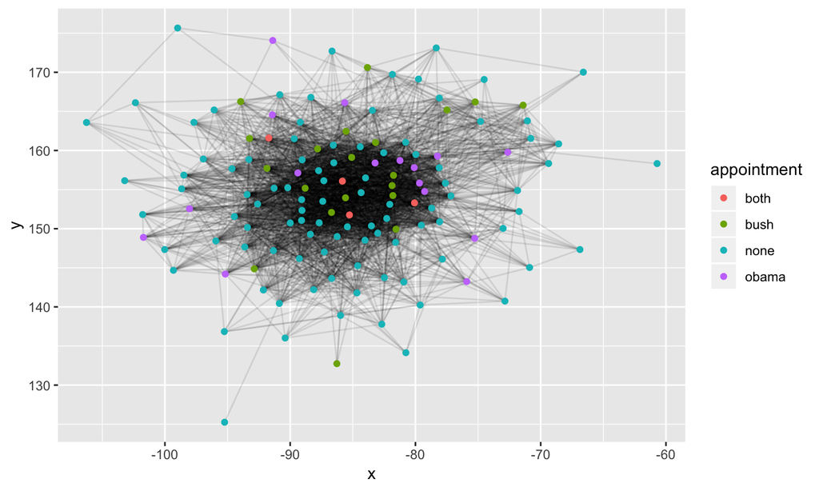

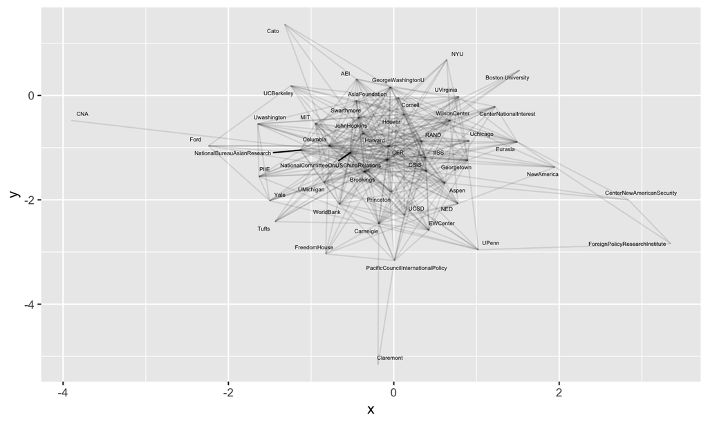

## Summary of Network

[output not shown]

## Centrality

|  | eigenvector | degree | betweenness |
| --- | --- | --- | --- |
| Network Centralization | 0.0682957 | 0.3544061 | 0.0264166 |
| Jonathan Pollack | 0.1358555 | 93.0000000 | 180.8967638 |
| Thomas Christensen | 0.1353500 | 92.0000000 | 169.0169265 |
| Mark Fung | 0.1348720 | 90.0000000 | 123.5878238 |
| Zbigniew Brzezinski | 0.1341440 | 90.0000000 | 130.2660387 |
| Robert Ross | 0.1339284 | 84.0000000 | 56.9436147 |
| Nancy Bernkopt Tucker | 0.1316814 | 85.0000000 | 112.6303601 |
| Elizabeth Economy | 0.1312826 | 87.0000000 | 151.4095130 |
| Harry Harding | 0.1311902 | 95.0000000 | 318.9620339 |
| Victor Cha | 0.1310688 | 88.0000000 | 165.2403535 |
| Taylor Fravel | 0.1309854 | 86.0000000 | 123.1497219 |
| John Mearsheimer | 0.1306294 | 87.0000000 | 107.5054723 |
| Joseph Nye | 0.1300922 | 90.0000000 | 247.3749433 |
| Kenneth Lieberthal | 0.1300781 | 85.0000000 | 181.0159755 |
| Cheng Li | 0.1300509 | 82.0000000 | 64.6210847 |
| Nicholas Lardy | 0.1295067 | 81.0000000 | 117.2148321 |
| Graham Allison | 0.1293431 | 84.0000000 | 82.2537748 |
| Stephen Bosworth | 0.1282349 | 81.0000000 | 63.7773353 |
| Michael Pillsbury | 0.1268914 | 85.0000000 | 126.6105766 |
| Richard Bush | 0.1261815 | 76.0000000 | 38.1867993 |
| Nicholas Eberstadt | 0.1257865 | 81.0000000 | 138.9415091 |
| Kent Calder | 0.1248522 | 77.0000000 | 50.3956101 |
| Elizabeth Perry | 0.1248514 | 74.0000000 | 25.9373610 |
| Jerome Cohen | 0.1248514 | 74.0000000 | 25.9373610 |
| Zalmay Khalilzad | 0.1244947 | 86.0000000 | 185.6888881 |
| Robert Legvold | 0.1242660 | 78.0000000 | 80.0567106 |
| Daniel Rosen | 0.1232172 | 74.0000000 | 32.5510221 |
| Evan Feigenbaum | 0.1228208 | 79.0000000 | 109.4430224 |
| Carla Anderson Hills | 0.1225869 | 76.0000000 | 50.4697675 |
| Susan Shirk | 0.1217940 | 78.0000000 | 195.3617680 |

[output cut: 117 more lines]

```
## Model:
##
## Call:
## stats::glm(formula = appointment_bush ~ betweenness, family = binomial("logit"),
##     data = as.data.frame(.))
##
## Deviance Residuals:
##     Min       1Q   Median       3Q      Max
## -1.3654  -0.5476  -0.4733  -0.4486   2.1662
##
## Coefficients:
##             Estimate (OR) Std. Error (OR) z value Pr(>|z|)
## (Intercept)      0.105870        0.033836  -7.026 2.12e-12 ***
## betweenness      1.010881        0.003307   3.308 0.000938 ***
## ---
## Signif. codes:  0 '***' 0.001 '**' 0.01 '*' 0.05 '.' 0.1 ' ' 1
##
## (Dispersion parameter for binomial family taken to be 1)
##
##     Null deviance: 130.49  on 145  degrees of freedom
## Residual deviance: 119.08  on 144  degrees of freedom
## AIC: 123.08
##
## Number of Fisher Scoring iterations: 4
```

[output not shown]

## Subgroup

## Block Model

## Some Challenges

- Cannot ruleout the non-network effect (Data)
  - Include some other personal data
- Modelling Issues
  - Still not clear whether the block model works or not
  - Specification of ERGM is not clear

## Looking Ahead

- Multiple networks
  - academic citation, journalist
- The network in other countries
- Long term changes of network